# A Graphical EDA Tool with ggplot2: brinton

We present [*brinton*](https://CRAN.R-project.org/package=brinton) package, which we developed for graphical exploratory data analysis in R. Based on [*ggplot2*](https://CRAN.R-project.org/package=ggplot2), [*gridExtra*](https://CRAN.R-project.org/package=gridExtra) and [*rmarkdown*](https://CRAN.R-project.org/package=rmarkdown), *brinton* package introduces `wideplot()` graphics for exploring the structure of a dataset through a grid of variables and graphic types. It also introduces `longplot()` graphics, which present the entire catalog of available graphics for representing a particular variable using a grid of graphic types and variations on these types. Finally, it introduces the `plotup()` function, which complements the previous two functions in that it presents a particular graphic for a specific variable of a dataset. This set of functions is useful for understanding the structure of a data set, discovering unexpected properties in the data, evaluating different graphic representations of these properties, and selecting a particular graphic for display on the screen.

Pere Millán-Martínez (Servei Català de Trànsit, Carrer Diputació) , Ramon Oller (Universitat de Vic - UCC)  
2021-01-15

## 1 Introduction

In 1977, J.W. Tukey noted that “The greatest value of a picture is when it *forces* us to notice what we never expected to see” (Tukey 1977 iv). This statement aligns with expectation disconfirmation theory (Oliver 1977), which links consumers’ satisfaction to their expectations. The field of exploratory data analysis (EDA) is characterized precisely by not requiring an expectation, since in this approach hypotheses may not be pre-established. Rather, they are allowed to emerge through the observation of the data. Additionally, because we cannot automate the processes of defining a problem or the corresponding hypotheses —as signaled by J. Bertin that same year (Bertin 1977 2)—, we face the challenge of automating graphical representations so that users can examine the data, develop hypotheses and then select the appropriate statistical graphic that will enable them to satisfy their recently created expectations.

The tools for generating graphics and statistics for a dataset automatically are called automated exploratory data analysis or autoEDA (Staniak and Biecek 2019). These tools facilitate some of the characteristic tasks of EDA, such as describing variables and validating observations or the relationships established between the values of one or more variables. *brinton*, a new package we have developed for use within R, shows only graphics, leading us to classify it as a tool for automated graphical exploratory data analysis or autoGEDA. We can include in this category tools such as [*GGobi*](https://CRAN.R-project.org/package=GGobi) (Cook et al. 2007) and [*Mondrian*](https://CRAN.R-project.org/package=Mondrian) (Theus and Urbanek 2008). These tools differ from *brinton* in that they use interactive techniques extensively, and therefore are usually classified as visual analytics.

Multiple strategies exist for automating statistical diagramatic representations. Millán-Martínez and Valero-Mora (2018) differentiate strategies according to whether they are based on the characteristics of the data (functional design, Kamps (1999)), on the habits of a group of users (collaborative filtering), on those of a single user (content-based filtering), on the tasks that the user is meant to perform (task design), on the characteristics of human perception (perceptual design), on the limitations of the communication channel or the screen on which the graphics are projected (responsive design), or, finally, on the selection of characteristics of the desired graphics or models of representation (representation model design or deterministic design).

The statistical programming environment R has two graphics systems (Friendly 2018). One is the standard graphics system of the package *graphics* with low-level functions, such as `lines()`, `points()`, `legend()` (which define concrete elements of a graphic) and high-level functions, such as `plot()`, `pie()`, and `barplot()` (which present a complete graphic). The other graphics system is based on the *grid* package, with low-level functions such as those of the *gridExtra* package (Auguie 2017) and high-level ones such as those of the packages [*lattice*](https://CRAN.R-project.org/package=lattice) (Sarkar 2008) and *ggplot2* (Wickham 2016), which produce complete graphics. Both in *graphics* and *grid* we find examples of the strategies mentioned above. We find functional design, for example, in the `plot()` function. If we apply it to the dataset `cars`, it produces a scatterplot, because it contains two numerical variables and is of the `data.frame` class. If we apply it to the dataset `airmiles`, it produces a line graph because this dataset has a single numerical variable and is of the `ts` class. We find task design in multiple packages, for example [*survminer*](https://CRAN.R-project.org/package=survminer) (Therneau 2015), which includes the function `ggsurvplot()` to generate graphics specifically for survival analysis. We find representation model design in basic functions such as `barplot()`, which produces a bar graph; `hist()`, which produces a histogram; and `pie()`, which produces a pie chart. We also see lower-level functions, such as the `geom_point()` function of *ggplot2*, which reduces the graphic to a kind of point plot. We can also find in *ggplot2* examples of perceptual design in decisions such as the default size, shape and color of the points, the grid lines and the panel background.

Despite all of the solutions already implemented in R, we are lacking an approach based on functional design that uses higher-level functions to show systematically not only a complete graphic but also a wide range of available graphics using the same data. Examining multiple graphics could lead the user to raise questions, which he or she could then answer using the presented graphics, new more specific graphics, or a particular graphic that could be adapted as needed (deterministic design). *brinton* package is our proposal for filling this gap in the R programming environment. We have named it after Willard Cope Brinton, whose Graphic Presentation (Brinton 1939) solved a similar problem for physical libraries.

The article is organized as follows: Section 2 briefly reviews the autoGEDA packages within R and also the variants of multipanel graphics. Section 3 presents the three functions of *brinton* package and the available graphic types in the specimen. Section 4 details the graphical degrees of freedom that this package enjoys in the moment of expanding the specimen. Section 5 describes the situations in which the functions are useful and Section 6 offers our conclusions and outline future work.

## 2 AutoGEDA and multipanel graphics

We classify *brinton* package within the autoGEDA tools we have described above. Another essential feature of this package is that it extensively combines different graphic types referring to the same records and variables in the form of multipanel graphics. A range of autoGEDA tools exist both outside and inside R. For the purposes of contextualizing *brinton*, we will concentrate on the solutions based in R.

### 2.1 The landscape of autoGEDA in R

Among the R packages dedicated to autoEDA (Staniak and Biecek 2019) only a few have a graphic orientation. We classify these packages according to their graphic solutions (although packages can have functions that offer different solutions).

Packages such as [*tabplot*](https://CRAN.R-project.org/package=tabplot) (Tennekes et al. 2013), [*visdat*](https://CRAN.R-project.org/package=visdat) (Tierney 2017) and [*inspectdf*](https://CRAN.R-project.org/package=inspectdf) (Rushworth 2019) use the structure plot, a graphic type that compacts all of the values of a dataset into a single panel. More specifically, *tabplot* and [*visdat*](https://CRAN.R-project.org/package=visdat) essentially offer variants of tableplots, which are static versions of the table lens (Rao and Card 1994), while *inspectdf* presents spine plots or bar charts, according to the type of summary to which the function `show_plot()` is applied. Another set of packages groups the variables of a dataset by type and represents the distribution of each variable in the cell of a multipanel graphic. This is the basic orientation of the packages [*xray*](https://CRAN.R-project.org/package=xray) (Seibelt 2017), [*DataExplorer*](https://CRAN.R-project.org/package=DataExplorer) (Cui 2019) and [*SmartEDA*](https://CRAN.R-project.org/package=SmartEDA) (Dayanand Ubrangala et al. 2019).

The packages [*dataMaid*](https://CRAN.R-project.org/package=dataMaid) (Petersen and Ekstrøm 2019) and [*summarytools*](https://CRAN.R-project.org/package=summarytools) (Comtois 2019) offer another way to observe all variables. These packages have functions that produce a descriptive summary of the variables along with a histogram or bar graph, depending on the type of variable. We also find packages with miscellaneous functions, each of which is aimed at facilitating the generation of an adhoc graphic type. This is the case, for example, of [*ExPanDaR*](https://CRAN.R-project.org/package=ExPanDaR), [*dlookr*](https://CRAN.R-project.org/package=dlookr), *summarytools* and [*explore*](https://CRAN.R-project.org/package=explore).

AutoEDA packages tend to have a double presentation of results: tabulated and graphical. Some of them, such as *dataMaid*, *summarytools* and *SmartEDA*, make it possible to generate automatic reports and even adapt these reports to the needs of a particular user. Despite the utility of the packages described here, they tend to offer few options for graphic presentation beyond the most widely used graphics. The relationships between the values of the variables can be revealed much more easily if multiple graphic types are presented. These packages lack a wider range of graphic alternatives.

### 2.2 Multipanel graphics

There are different types of multipanel graphics depending on the diversity of graphic types and the origin of the data. On one hand, we have dashboards, which generally combine different graphic types in a limited space. Dashboards can draw from different data sources and are particularly useful for monitoring complex processes. Graphics of this type are implemented in R through packages such as [*shinydashboard*](https://CRAN.R-project.org/package=shinydashboard) (Chang and Borges Ribeiro 2018) and [*flexdashboard*](https://CRAN.R-project.org/package=flexdashboard) (Iannone et al. 2018). The `plot_grid()` function of the package [*cowplot*](https://CRAN.R-project.org/package=cowplot) (Wilke 2019) offers the possibility of combining graphics of the same or different type without space restrictions by creating multipanel graphics. This can also be achieved with the [*patchwork*](https://CRAN.R-project.org/package=patchwork) package (Pedersen 2019) that adds versatility to the composition of multipanel graphics by introducing operators that partition the canvas.

A second type of multipanel graphic is the conditioning plot[^1]. In these, the same graphic type is repeated in different panels at the same scale, representing subsets of data according to the level of one or more variables. A third type of multipanel graphic is the matrix of plots, which links pairs of variables of the same type and from the same dataset. A classic example is the scatterplot matrix (Hartigan 1975), or, more recently, the HE plot (Friendly 2007). The diagonal of these grids can be populated with a different graphic type, since a single variable is involved. A variant of the matrix of plots uses source variables of different types that, when paired, result in a grid with multiple graphic types, depending on how the variables are combined. This graphic type is known as a generalized pairs plot (Emerson et al. 2013).

## 3 The brinton package

We created *brinton* package to facilitate exploratory data analysis following the visual information-seeking mantra (Shneiderman 1996): “Overview first, zoom and filter, then details on demand.” The main idea is to assist the user during these three phases through three functions: `wideplot()`, `longplot()` and `plotup()`. A distinctive feature is the following: the `wideplot()` function provides a limited selection of available graphics for all the variables in a data frame, the `longplot()` function provides all the range of available graphics for a limited selection of variables and, finally, the `plotup()` function provides one single graphic for a limited selection of variables. While each of these functions has its own arguments and purpose, all three serve to facilitate exploratory data analysis and the selection of a suitable graphic.

The `wideplot()` function allows the user to explore a dataset as a whole using a grid of graphics in which each variable is represented through multiple graphics. Once we have explored the dataset as a whole, the `longplot()` allows us to explore other graphics for a given variable. This function also presents a grid of graphics, but instead of showing a selection of graphics for each variable, it presents the full range of graphics available in the package to represent a single variable. Once we have narrowed in on a certain graphic, we can use the `plotup()` function, which presents the values of a variable on a single graphic. We can access the code of the resulting graphic and adapt it as needed. These three functions expand the graphic types that are presented automatically by the autoGEDA packages in the R environment.

*brinton* package is based primarily in the grammar of graphics (Wilkinson 2005) implemented in R by the package *ggplot2*. Additionally, it draws on the package *gridExtra* (Auguie 2017) for creating multipanel graphics and on *rmarkdown* (Allaire et al. 2019) for dynamically composing the results.

In the context of graphics packages in R based on the *grid* system, the package *lattice* allows the user to create a range of some 13 graphic types, which can be adapted to a very fine level of detail. *ggplot2* makes it possible to control even the finest detail of a graphic, but this comes at the price of learning its grammar and its layer system. In contrast, *brinton* package makes it possible for the user to select statistical graphics by name from a wide range of available graphics and, if he or she knows the grammar of *ggplot2*, adapt them as needed. To create a statistical graphic in R, if the desired graphic is already implemented in *brinton* package, the user must simply specify the data source and the graphic type to be produced.

The package can be installed easily from the Comprehensive R Archive Network (CRAN) using the R console. When the package is loaded into memory, it provides a startup message that pays homage to Henry D. Hubbard’s enthusiastic introduction to the book Graphic Presentation (Brinton 1939):

```r
  install.packages("brinton")
  library(brinton)
```

```r
  M a G i C i N G R a P H S
```

### 3.1 The wideplot function

When a dataset is loaded into R, the next function to be used tends to be `str()`. This occurs because if we don’t determine the nature of the values explicitly, the functions for loading datasets make assumptions about it. The function `str()` shows in the console the type of object to which the function is being applied, the number of rows, the number and names of columns, their class (number, factor, etc.) and the initial observations for each variable. The `wideplot()` function takes inspiration from this function, but instead of describing the dataset in textual or tabular form, it does it graphically. We can easily compare the results of these two functions, for example, with the dataset `esoph` from a case-control study of esophageal cancer in Ille-et-Vilaine, France. The dataset has three ordered factor-type variables and two numerical variables:

```r
  str(esoph)
```

```
#> 'data.frame':    88 obs. of  5 variables:
#>  $ agegp    : Ord.factor w/ 6 levels "25-34"<"35-44"<..: 1 1 1 1 1 1 1 1 1 1 ...
#>  $ alcgp    : Ord.factor w/ 4 levels "0-39g/day"<"40-79"<..: 1 1 1 1 2 2 2 2 3 3 ...
#>  $ tobgp    : Ord.factor w/ 4 levels "0-9g/day"<"10-19"<..: 1 2 3 4 1 2 3 4 1 2 ...
#>  $ ncases   : num  0 0 0 0 0 0 0 0 0 0 ...
#>  $ ncontrols: num  40 10 6 5 27 7 4 7 2 1 ...
```

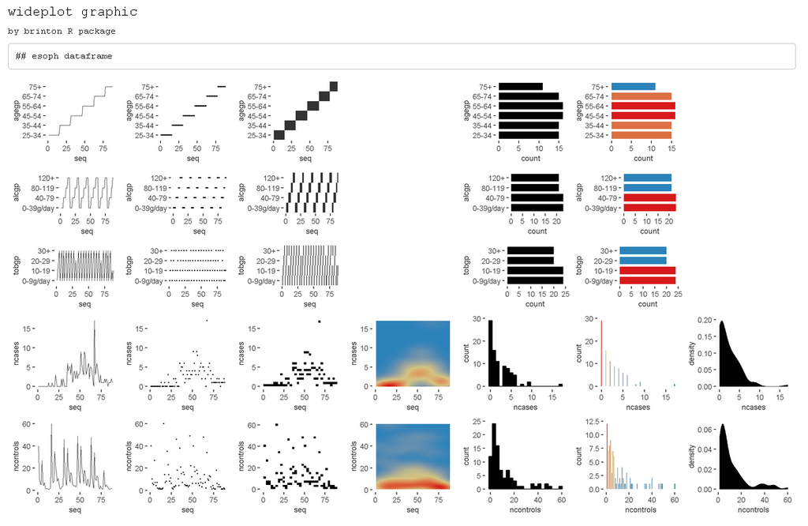

Figure 1: Output of `wideplot(esoph)`. A grid of graphics in which each row corresponds to a variable in the dataset `esoph` and each column displays different available graphics.

```r
  wideplot(data = esoph)
```

The `wideplot()` function creates html files, as side-effects, with a graphical summary (See Figure 1) of the variables included in the dataset to which it has been applied. First it groups the variables according to the following sequence: logical, ordered, factor, character, datetime and numeric. Next, it creates a multipanel graphic in html format, in which each variable of the dataset is represented in a row of the grid, while each column displays the different available graphics for each variable. We called the resulting graphic type *wideplot* because it shows a range of graphics for all of the columns of the dataset. The structure of the function, the arguments it permits and its default values are as follows:

```
#> wideplot(data, dataclass = NULL, logical = NULL, ordered = NULL,
#>   factor = NULL, character = NULL, datetime = NULL, numeric = NULL,
#>   group = NULL, ncol = 7, label = 'FALSE')
```

The only argument necessary to obtain a result is `data` that expects a `data.frame` class object; `dataclass` selects and sorts the types of variables to be shown; `ncol` filters the first *n* columns of the grid, between 3 and 7, which will be shown. The fewer columns displayed, the larger the size of the resulting graphics, a feature that is especially useful if the scale labels dwarf the graphics area; `label` adds to the grid a vector below each group of rows according to the variable type, with the names and order of the graphics; `logical`, `ordered`, `factor`, `character`, `datetime` and `numeric` make it possible to choose which graphics, from among the ones included by the specimen (Sec. 3.4), appear in the grid and in what order, for each variable type. Finally, `group` changes the selection of graphics that are shown by default according to the criteria of Table 1.

If the order and graphic types to be shown for each variable type are not specified and if the graphic types aren’t filtered using the argument `group`, then the default graphic will contain an opinion-based selection of graphics for each variable type, organized especially to facilitate comparison between graphics of the same row and between graphics of the same column. The user can overwrite this selection of graphics as needed, using the arguments `logical`, `ordered`, `factor`, `character`, `datetime` and `numeric`.

Table 1: Possible values for the `group` argument of the `wideplot()` function.

| **group** | **graphic type** |
| --- | --- |
| `sequence` | includes the sequence in which the values are observed so that an axis |
|  | develops this sequence. e.g. line graph, point-to-point graph |
| `scatter` | marks represent individual observations. e.g. point graph, stripe graph |
| `bin` | marks represent aggregated observations based on class intervals. |
|  | e.g. histogram, bar graph |
| `model` | represents models based on observations. e.g. density plot, violin plot |
| `symbol` | represents models based on observations. and not only points, lines or areas |
|  | e.g. box plot |
| `GOF` | represents the goodness of fit of some values with respect to a model |
|  | e.g. qq plot |
| `random` | chosen at random |

### 3.2 The longplot function

To facilitate economy of calculation, the `wideplot()` function presents a limited number of graphics in each row. If the user wants to expand the range of suggested graphics for a given variable, he or she should use the `longplot` function, which returns a grid with all of the graphics considered by the package (See Figure 2) for that variable. The structure of the function is very simple `longplot(data, vars, label = TRUE)` and we can easily check the outcome of applying this function to the variable `alcgp` of the dataset `esoph`:

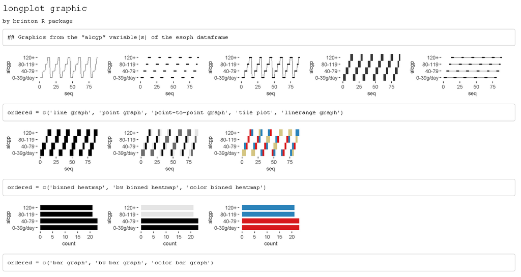

Figure 2: Output of `longplot(esoph, ’alcgp’)`. A grid of graphics where the variable `alcgp` in the dataset `esoph` is displayed for the full range of graphics considered by the package.

```r
  longplot(data = esoph, vars = "alcgp")
```

We named the resulting graphic type *longplot* because it shows the full range of available graphics to represent the relationships among the values of a limited selection of variables (although for now, in this package we have only included graphics for a single variable).

The arguments of the function are `data`, which must be a `data.frame` class object; `vars`, which requires the name of a specific variable of the dataset; and `label`, which does not have to be defined and which adds a vector below each row of the grid indicating the name of each graphic. Unlike the grid of the `wideplot` function, the grid of the `longplot` function does not include parameters to limit the range of graphics to be presented. We made this decision because the main advantage of this function is precisely that it presents all of the graphic representations available for a given variable. However, we do not rule out adding filters that limit the number of graphics to be shown if this feature seems useful as the catalog fills with graphics. Each graphic presented can be called explicitly by name using the functions `wideplot()` and `plotup()`, which is why the argument `label` has been set to `TRUE` by default in this case.

The range of graphics that the `longplot()` function returns is sorted so that in the rows we find different graphic types and in the columns different variations of the same graphic type. This organization, however, is not absolute and in some cases in order to compress the results, we find different graphic types in the same row.

### 3.3 The plotup function

The `plotup()` function has the following structure: `plotup(data, vars, diagram, output = ’plots pane’)`. By default, this function returns an object belonging to class `gg` and `ggplot` whose graphic can be rendered in the plots pane of RStudio. This graphic is based on a variable from a given dataset and the name of the desired graphic, from among the names included by the specimen that we present in the next subsection. We can easily check the outcome of applying this function to produce a line graph from the variable `ncases` of the dataset `esoph` (See Figure 3) :

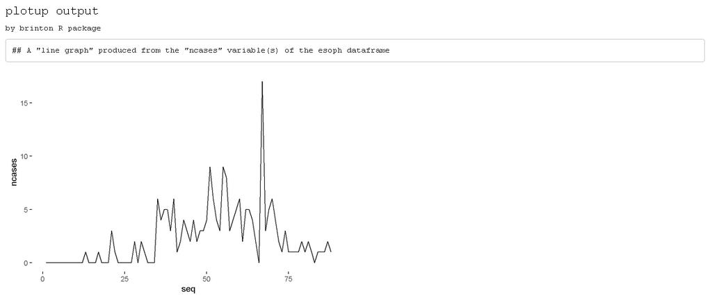

Figure 3: Output of `plotup(esoph, ’ncases’, ’line graph’)`. A line graph from the variable `ncases` in the dataset `esoph`.

```r
  plotup(data = esoph, vars = 'ncases', diagram = 'line graph', output = 'html')
```

This function requires three arguments: `data`, `vars` and `diagram`. The fourth argument, `output`, is optional and has the default value of `plots pane`. However, if is set to it `html` or `console`, instead of returning a `c("gg", "ggplot")` object, the function cause a side-effect: either creating and displaying a temporary html file, or printing the ggplot2 code to the console. This feature is especially useful to adapt the default graphic to the specific needs and preferences of the user.

The `diagram` argument accepts any of the values admitted by the `logical`, `ordered`, `factor`, `character`, `datetime` and `numeric` arguments of the `wideplot()` function. These values coincide with the names of the graphics considered by the package and included in the specimen. The naming convention of these graphs is implicitly addressed in Section 4 “Graphical degrees of freedom”.

```r
  plotup(data = esoph, vars = 'ncases', diagram = 'line graph',
         output = 'console')
```

```
#> ggplot(esoph, aes(x=seq_along(ncases), y=ncases)) +
#>   geom_line() +
#>   labs(x='seq') +
#>   theme_minimal() +
#>   theme(panel.grid = element_line(colour = NA),
#>     axis.ticks = element_line(color = 'black'))
```

### 3.4 The specimen

The documentation of the package includes the vignette “1v specimen”, which contains a specimen with images of all the graphic types for a single variable, incorporated into the package according to the variable type. These graphics serve as an example so that the user can rapidly check whether a graphic has been incorporated, the type or types of variable for which it has been incorporated, and the label with which it has been identified. The suitability of a particular graphic will depend on the datasets of interest and the variables of each particular user. We have incorporated this specimen in its current version as supplementary material.

## 4 Graphical degrees of freedom

The utility of this package is based on the fact that different graphical representations of the same data make it possible not only to observe different characteristics of the data, but also to show a certain characteristic more effectively. For this reason, the graphics considered by this package enjoy a large number of graphical degrees of freedom. This makes it possible for the catalog to include both commonly used graphics and graphics that have not yet been developed. The concept of graphical degrees of freedom has been used by Benger and Hege (2006) to refer to Bertin’s visual variables (1967 43) but with some modifications. Here we use the concept in a broader sense, as detailed below.

- **Type of graphic**. The main degree of freedom of the graphics catalog is the graphic type. The different graphic types are not necessarily ones that differ greatly from each other. To the contrary, very similar graphics coexist because a high number of users prefer each of them. This is the case, for example, of the density plot and the violin plot shown in Figure 4.

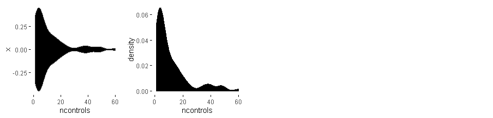

Figure 4: 1st degree of freedom (type of graphic). Density and violin plots of variable `ncontrols` (in the dataset `esoph`).

```r
  wideplot(data = esoph[5],
           numeric = c('filled violin plot', 'filled density plot'))
```

- **Chromatic scales**. The same graphic can have different versions depending on the chromatic scale associated with a variable in the data or computed from it. We can see an example of this in the following figure 5. Despite the fact that color can be broken down into the three visual variables of hue, saturation and value, for the purposes of this package we have only taken into account hue in the case of the color scale and value in the case of the grayscale, following Bertin’s classification of visual variables (1967 43).

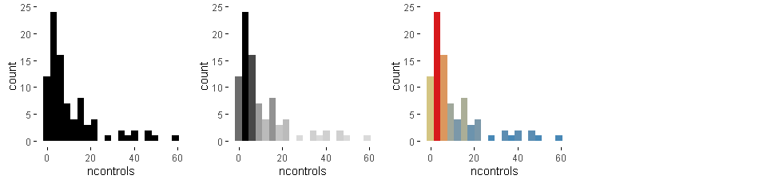

Figure 5: 2nd degree of freedom (chromatic scale). Plots of variable `ncontrols` (in the dataset `esoph`) with different chromatic scales.

```r
  wideplot(data = esoph[5],
           numeric = c('histogram', 'bw histogram', 'color histogram'))
```

- **Agreggation method: scattered or binned**. The same values can be represented such that each mark represents either a single value or an aggregate value. An example of this feature can be observed in Figure 6.

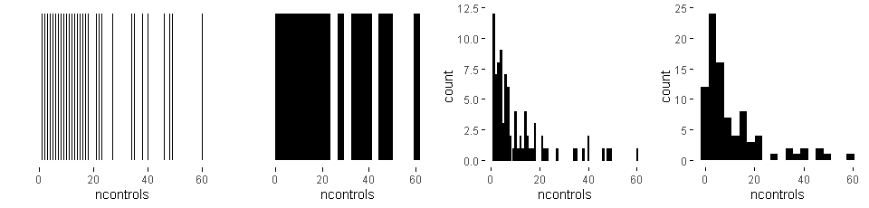

Figure 6: 3rd degree of freedom (aggregation method). Plots of variable `ncontrols` (in the dataset `esoph`) with single or aggregate values.

```r
  wideplot(data = esoph[5],
           numeric = c('stripe graph', 'binned stripe graph', 'bar graph',
                       'histogram'))
```

- **Nested panels**. One possibility (which has been little explored) is that of subdividing into different panels the cells of the multipanel graphic, to create systems of coordinates inside systems of coordinates. This solution is similar to the treemap. In the example in Figure 7, the graphic on the right has three panels that can substitute the first three graphics.

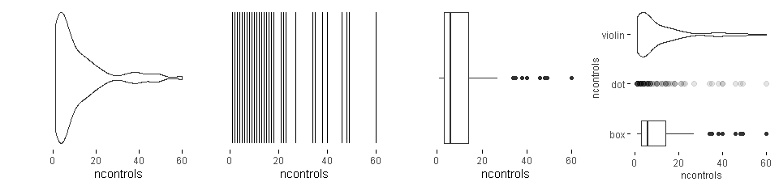

Figure 7: 4th degree of freedom (nested panels). Plots of variable `ncontrols` (in the dataset `esoph`) with single and multiple panels (the first three ones and the last one respectively).

```r
  wideplot(data = esoph[5],
           numeric = c('violin plot', 'stripe graph', 'box plot', '3 uniaxial'))
```

- **Shape**. The same information can be represented with marks of different shapes. This possibility is exemplified in Figure 8, which compares two graphics with similar composition but different marks: circular or square.

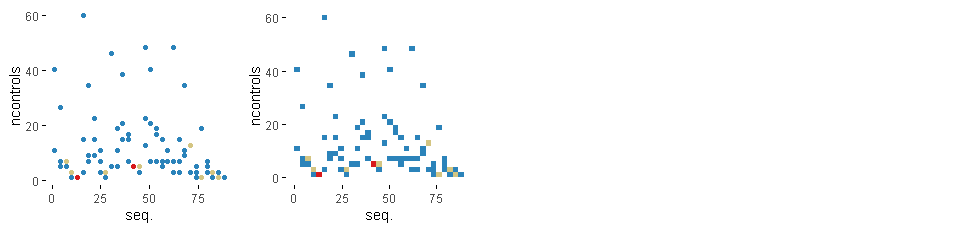

Figure 8: 5th degree of freedom (shape). Plots of variable `ncontrols` (in the dataset `esoph`) with marks of different shapes.

```r
  wideplot(data = esoph[5],
           numeric = c('color binned point graph', 'color binned heatmap'))
```

- **Implantation**. The same values can be represented with marks of a different type of implantation, such as a point, a line, an area or a combination of these. For example, Figure 9 compares a point graph, a line graph, and a point-to-point graph.

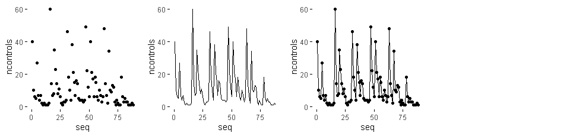

Figure 9: 6th degree of freedom (implantation). Plots of variable `ncontrols` (in the dataset `esoph`) with marks of a different type of implantation.

```r
  wideplot(data = esoph[5],
           numeric = c('point graph', 'line graph', 'point-to-point graph'))
```

- **Transition**. The transition or itinerary between two points can help reflect the discrete nature of the changes in the values observed. Figure 10 compares two line graphs with different transitions between points.

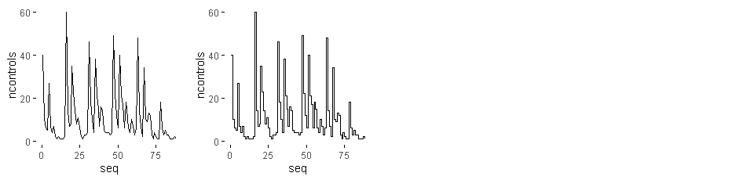

Figure 10: 7th degree of freedom (transition). Plots of variable `ncontrols` (in the dataset `esoph`) with different transitions between points.

```r
  wideplot(data = esoph[5],
           numeric = c('line graph', 'stepped line graph'))
```

- **Collation**. The values of variables, especially those that aren’t related to order, can be sorted according to different criteria. This package, as shown in Figure 11 uses three: the order of appearance in the sequence of observations, the frequency with which the values are observed and alphabetical order.

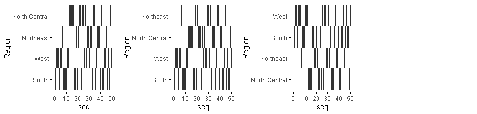

Figure 11: 8th degree of freedom (collation). Plots of variable `Region` with the values sorted according to different criteria.

```r
  wideplot(data = data.frame('Region' = state.region),
           factor = c('tile plot',
                      'freq. reordered tile plot',
                      'alphab. reordered tile plot'))
```

- **Superposition**. The final degree of freedom that we consider is the possibility of including graphics that superpose marks whose data source is the same but that have different degrees of transformation (see Figure 12).

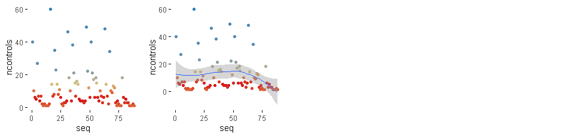

Figure 12: 9th degree of freedom (superposition). Plots of variable `ncontrols` (in the dataset `esoph`) with and without the superposition of a trend line.

```r
  wideplot(data = esoph[5],
           numeric = c('color point graph',
                       'color point graph with trend line'))
```

To construct the specimen we have ruled out some degrees of freedom, for example, the group of imposition (Bertin 1967 52) and the permutation of spacial variables (Bertin 1967 43). In other words, *brinton* package exclusively presents diagrams and not networks or maps, nor does it show alternatives whose only difference is that the *x* and *y* axes are switched.

## 5 Application to real datasets

The main application of a package for exploratory data analysis is to help the user make sense of the data. This includes describing the number and nature of the variables, the number of observations and examples of the variables–this is precisely what the `str()` function does. It also includes evaluating the validity and quality of the data and the properties of the values found.

We can deduce the number of variables from the number of rows in the grid of the wideplot graphic. The names of the variables are found in each of the graphics that the catalog now contains. We can determine the variables’ nature–in terms of the measurement scale—-by observing the range of graphics selected and specifying the value `label = TRUE` for the grids of wideplot and longplot graphics. We can discern the number of observations by examining the graphics that include the sequence of observations or, in the case of categorical variables, by counting the categories and the number of observations for each one. Wideplot graphics, in contrast to the textual summary of the `str()` function, show examples not only of the first observations but of all observations. To evaluate the validity of the data, we can observe specific graphics that allow us to identify outliers, missing values or discontinuity in the observations. The same goes for the properties of the values found. There is a huge range of graphics, each of which makes it possible to highlight different properties. Below we list a series of tasks for which the functions included in *brinton* are useful, and describe the process for carrying them out.

### 5.1 Identify multi-column sorting

Here we describe how to use the `wideplot()` function to determine whether the observations of the dataset `aids` of the package [*KMsurv*](https://CRAN.R-project.org/package=KMsurv) are sorted according to one of the variables. This dataset has three variables, `infect` (infection time for AIDS in years), `induct` (induction time for AIDS in years), and `adult` (indicator of adult: 1=adult, 0=child). To accomplish the task, we first install the package, then load it into memory and run the wideplot function with its default output.

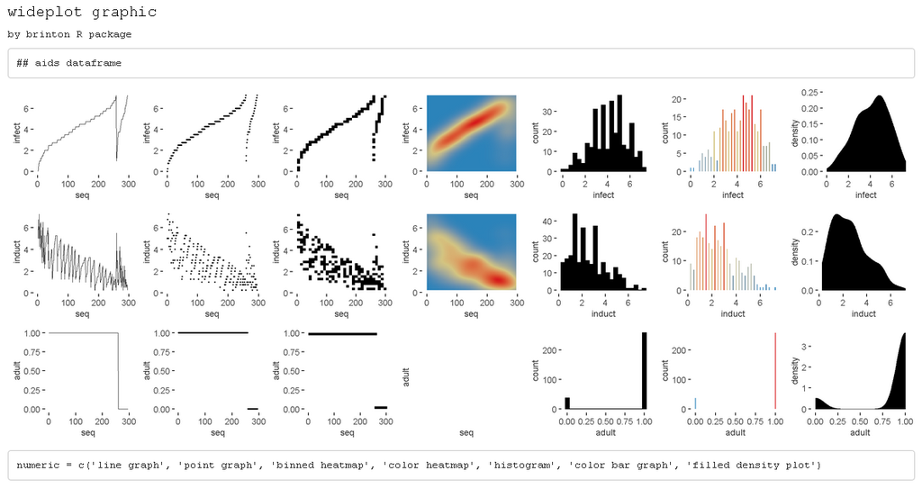

Figure 13: A grid of graphics generated by `wideplot(aids, label = T)`. Each row corresponds to a variable in the dataset `aids`. The line graph shows that the dataset is sorted first by the variable `adult` and then by the variable `infect`.

```r
  install.packages('KMsurv')
  data(aids, package = 'KMsurv')
  wideplot(data = aids, label = TRUE)
```

From the result in Figure 13, we observe that the line graph is the one that best shows that the dataset is sorted first by the variable `adult` and then by the variable `infect`. To finish selecting the most suitable graphic we can then execute the same function but limit the graphic types such that only two variations of line graph are shown. We can moreover limit the function so that it displays, for example, only five columns, so that the graphics will be larger.

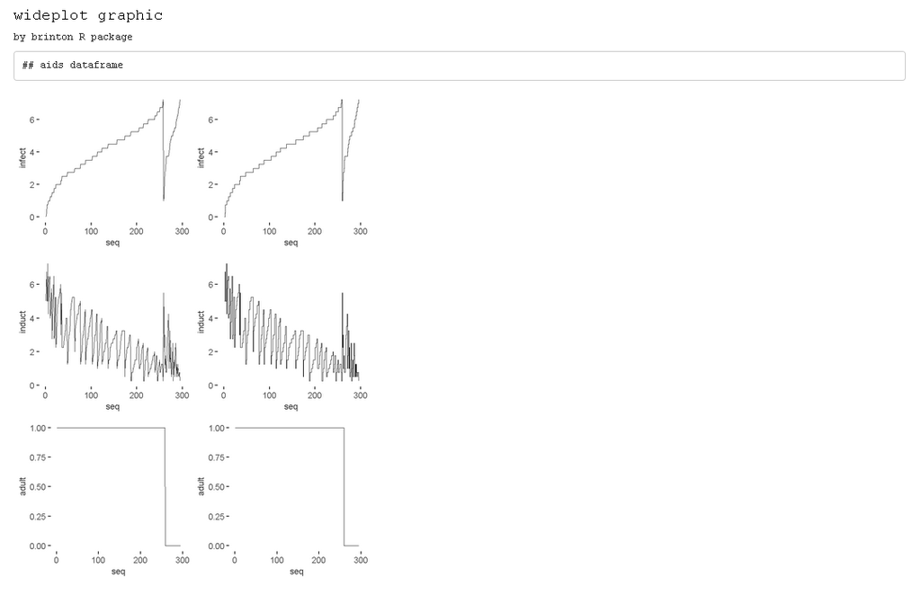

Figure 14: A grid of graphics generated by `wideplot(aids, numeric = c(’line graph’, ’stepped line graph’), ncol=5)`. Each row corresponds to a variable in the dataset `aids`. Graphic types are limited to line and stepped line types.

```r
  wideplot(data = aids,
           numeric = c('line graph', 'stepped line graph'), ncol = 5)
```

The result is two variations of the line graph for each variable, in which we can clearly see that the data set is sorted first by the variable `adult` and then by the variable `infect`. In this case, there may be equally valid arguments for using the graphics of the first column as the graphics of the second column.

This same example also works for datasets with categorical variables, such as the dataset MentalHealth of the package [*Stat2Data*](https://CRAN.R-project.org/package=Stat2Data). This dataset consists of three variables: `Month` (month of the year); `Moon` (relationship to full moon: `After`, `Before`, or `During`); and `Admission` (number of emergency room admissions). The first two variables are categorical and the third is numerical. If we examine the line graph and also the tile plot for the factor-type variables and the binned heatmap graphic for the numerical variables, we can easily see that the dataset is sorted by the variable `Moon` and then by the variable `Month` (see Figure 15).

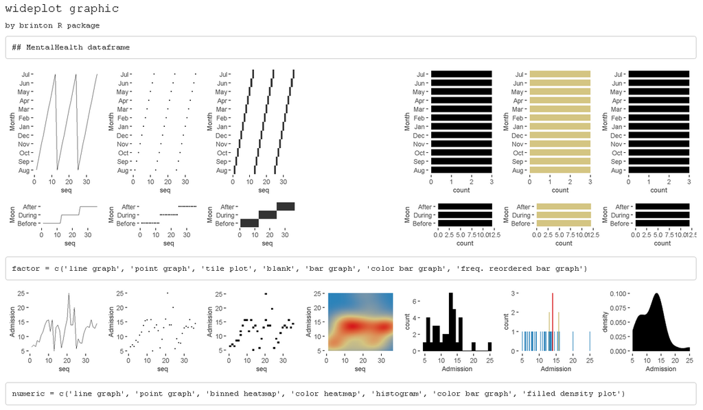

Figure 15: A grid of graphics generated by `wideplot(MentalHealth, label = T)`. Each row corresponds to a variable in the dataset `MentalHealth`. It is observed that the dataset is sorted by the variable `Moon` and then by the variable `Month`.

```r
  install.packages('Stat2Data')
  data(MentalHealth, package = 'Stat2Data')
  wideplot(data = MentalHealth, label = TRUE)
```

### 5.2 Identify variables that can be reclassified

When loading a dataset it is important to check which assumptions the function has made and which variables can be reclassified. We can see an example of this in Figure 14, which shows that the variable `adult` of the dataset `aids` is better treated as a logical-type variable than an integer. If we recode the variable type more appropriately, when we apply the `wideplot()` function again, the graphics also tend to be more appropriate. In Figure 16 we see the result after the variable `adult` is reclassified.

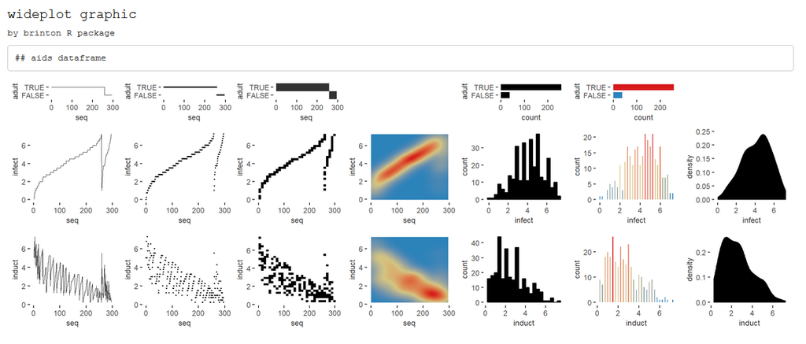

Figure 16: A grid of graphics generated by `wideplot(aids)`. Each row corresponds to a variable in the dataset `aids`. The variable `adult` has been reclassified from integer to logical in order to obtain more appropriate graphics.

```r
  aids$adult <- as.logical(aids$adult)
  wideplot(data = aids)
```

### 5.3 Identify key variables

The best way to identify key variables is by using complementary graphics. Figure 17 makes it possible, for example, to identify rapidly the variable `patient` of the dataset `azt` in the package *KMsurv*, as a key variable, given that it assigns a sequential number to each record, each of which is observed a single time. We can draw these two conclusions from the line graph and the color bar graph.

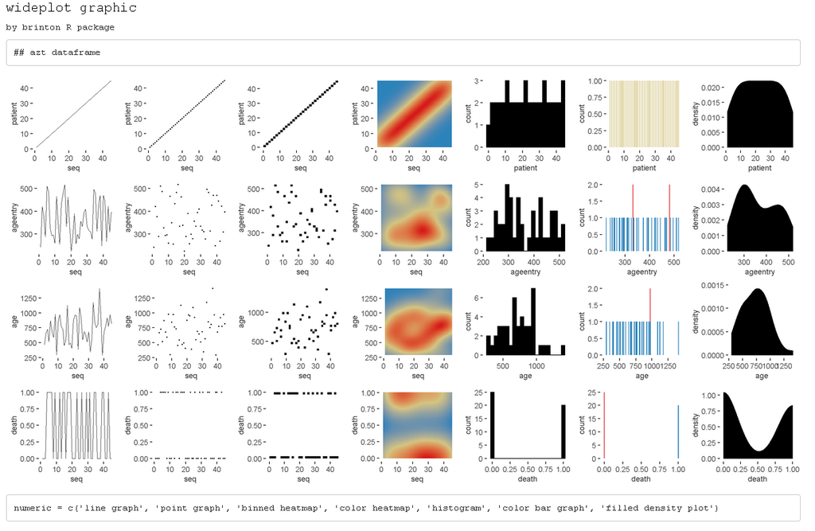

Figure 17: A grid of graphics generated by `wideplot(azt, label=TRUE)`. Each row corresponds to a variable in the dataset `azt`. The line graph and the color bar graph recognize the variable `patient` as a key variable that assigns a sequential number to each record.

```r
  data(azt, package = 'KMsurv')
  wideplot(data = azt, label = TRUE)
```

In the case of categorical key variables, the same line graph and color bar graph would also help us to identify the key variable. Figure 18 shows these two graphs for the factor-type variable of the dataset `SpeciesArea` in the package *Stat2Data*, which allow us to identify rapidly the variable `Name` as a key variable.

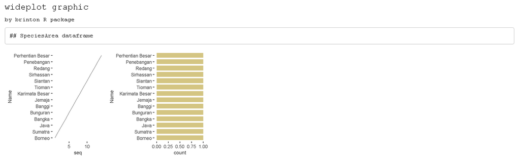

Figure 18: Line and color bar graphs of the factor-type variable `Name` (in the dataset `SpeciesArea`) produced by the function `wideplot()`. It is observed that the variable `Name` is a key variable since the values are not repeated and observed once.

```r
  data(SpeciesArea, package = 'Stat2Data')
  wideplot(data = SpeciesArea, dataclas = c('factor'),
           factor = c('line graph', 'color bar graph'), ncol = 5)
```

### 5.4 Be surprised by serendipity

Next we describe isolated cases in which we are surprised by the values that the data depict. We use the following procedure to locate unexpected aspects of the data: first we obtain a general view of the dataset using the function `wideplot()`; next we focus our attention on one variable in particular and explore all of the compatible graphics using the function `longplot()`; finally, we use the function `plotup()` to obtain the graphic that best enables us to identify, narrow down and communicate the aspect of the data that we have found.

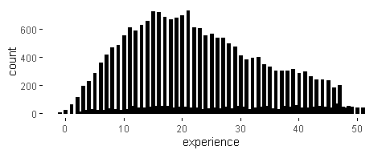

Figure 19: Bar plot of the variable `experience` (in the dataset `HI`) produced by the function `plotup()`. It is observed that the frequency of the whole values is systematically greater than the frequency of the real non-whole values.

```r
  data(HI, package = 'Ecdat')
  HI_sam <- HI[sample(nrow(HI), 5000), ]
  wideplot(data = HI_sam)                      # Output not reproduced here
  longplot(data = HI_sam, vars = 'experience') # Output not reproduced here
  plotup(data = HI_sam, vars = 'experience', diagram = 'bar graph')
```

- In the same dataset we can see that we could reach mistaken conclusions about the distribution of the variable `husby` (husband’s income in thousands of dollars) if we only looked at a histogram. As we can see in Figure 20, the distribution, and in particular the value zero, acquires a different value if we compare the histogram (left) with another graphic that isn’t as common for numerical variables: the bar graph (right), which shows the count of unique values. The bar graph makes it possible to clearly differentiate two groups: the informants whose husbands have no income and the informants whose husbands do have income (and to whom, therefore, it makes more sense to ask approximate income).

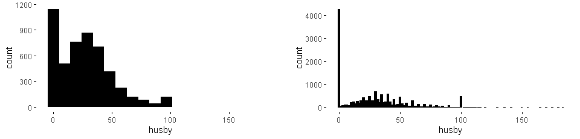

Figure 20: Histogram (left) and bar plot (right) of the variable `husby` (in the dataset `HI_sam`) produced by the function `plotup()`. The bar plot makes it possible to identify the zero as a value with a special meaning.

```r
  library(patchwork)
  plotup(HI_sam, 'husby', 'histogram') + plotup(HI_sam, 'husby', 'bar graph')
```

### 5.5 Combine graphics that best explains a specific data characteristic

Just as multipanel graphics make it possible to reveal different aspects of the data, it can also be helpful to use a selection of graphics to present a certain characteristic of the data. Next, we show an example of how *brinton* package can help us improve the default graphics in order to combine them later to show a particular feature.

- A recurring problem when we deal with datasets with many records is that when marks overlap, we cannot correctly interpret the set of observations. The presentation of multiple graphics to represent the same values enables us to identify these overlaps and improve the representation that the package shows by default. For example, in Figure 21 we can see how the point graph for the same variable `husby` is unclear because the marks overlap.

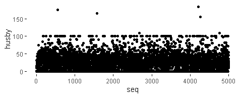

Figure 21: Point plot of the variable `husby` (in the dataset `HI_sam`) produced by the function `plotup()`. The point plot does not identify the zero as a value with a special meaning because the marks overlap.

```r
  plotup(data = HI_sam, vars = 'husby', diagram = 'point graph')
```

- We do not have to accept the default result. Rather we can retrieve the package’s *ggplot2* function using the argument `output = ’console’` and then improve it:

```r
  plotup(data = HI_sam, vars = 'husby', diagram = 'point graph',
  output = 'console')
```

```
#> ggplot(HI_sam, aes(x=seq_along(husby), y=husby)) +
#>   geom_point() +
#>   labs(x='seq') +
#>   theme_minimal() +
#>   theme(panel.grid = element_line(colour = NA),
#>     axis.ticks = element_line(color = 'black'))
```

- In this case we can, for example, improve the graphic by reducing the size of the points and adding an alpha channel (see Figure 22).

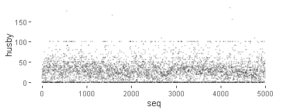

Figure 22: New point plot of the variable `husby` (in the dataset `HI_sam`) produced by the functions `plotup()` and `ggplot()`. Now the point plot makes it possible to identify the zero as a value with a special meaning.

```r
  newpointgraph <- ggplot(HI_sam, aes(x=seq_along(husby), y=husby)) +
  geom_point(size = 0.3, alpha = 0.15) +
  labs(x='seq') +
  theme_minimal() +
  theme(panel.grid = element_line(colour = NA),
  axis.ticks = element_line(color = 'black'))

  newpointgraph
```

- One option for this graphic that isn’t affected by the overlapping of marks is the heatmap, and yet another is the bar graph that represents the frequency with which the unique values are observed. Combining the three graphics helps to highlight different aspects in order to make it easier to understand the data. Figure 23 shows how to combine the three graphics. Note that the bar graph has been rotated 90 degrees to become a marginal plot, following the grammar implemented in *ggplot2*, to facilitate the correspondence between individual observations, the density that can be deduced from them, and the frequency of unique values. Also, the axis labels have been adjusted to avoid unnecessary repetition.

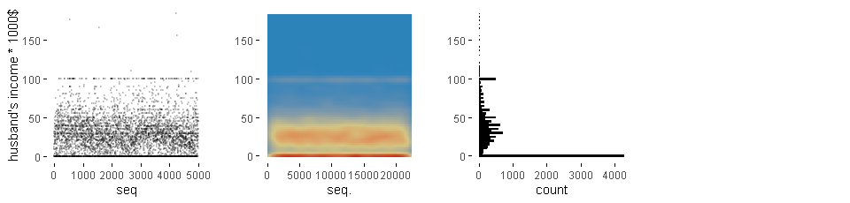

Figure 23: Multipanel graphic as a composition of three plots of the variable `husby` (in the dataset `HI_sam`). The source of each plot is the function `plotup()`. Combining the three plots helps to highlight different aspects of the distribution of the variable `husby`.

```r
  newpointgraph + labs(y = "husband's income * 1000$") +
  plotup(data = HI_sam, vars = 'husby', diagram = 'color heatmap') +
  labs(y = '') +
  plotup(data = HI_sam, vars = 'husby', diagram = 'bar graph') +
  labs(x = '') + coord_flip()
```

The resulting multipanel graphic shows that throughout the dataset, the revenue distribution remains essentially constant, highlighting the number of husbands without income and rounding the reported values to nice numbers such as 25, 30, 40, 50 and 100–although in reality, the value that draws a horizontal line around 100 is, surprisingly, 99,999. And here we have another mystery to solve.

## 6 Conclusions

We have introduced *brinton* package, a graphical EDA tool designed to facilitate the presentation, selection and editing of statistical graphics built on *ggplot2*. This package maximizes the deterministic strategy of graphic selection by presenting a range of graphics that a user can choose by name, automating the construction of graphics and even allowing the user to recover the underlying *ggplot2* function in order to adapt the graphics as necessary. This package makes it easier for a user to become familiar with a dataset and generate hypotheses based on it.

This is a project in progress and new software implementations are being updated and released. We plan to create a fuller catalog that will include graphics that can combine up to three variables, improve the aesthetics of the default graphics and add new functions for autoGEDA.

## 7 Acknowledgements

### 7.1 CRAN packages used

brinton, ggplot2, gridExtra, rmarkdown, GGobi, Mondrian, lattice, survminer, tabplot, visdat, inspectdf, xray, DataExplorer, SmartEDA, dataMaid, summarytools, ExPanDaR, dlookr, explore, shinydashboard, flexdashboard, cowplot, patchwork, KMsurv, Stat2Data, Ecdat

### 7.2 CRAN Task Views implied by cited packages

ChemPhys, Econometrics, NetworkAnalysis, Phylogenetics, ReproducibleResearch, Spatial, Survival, TeachingStatistics, TimeSeries

J. Allaire, Y. Xie, J. McPherson, J. Luraschi, K. Ushey, A. Atkins, H. Wickham, J. Cheng, W. Chang and R. Iannone. *Rmarkdown: Dynamic documents for r.* 2019. URL https://rmarkdown.rstudio.com. R package version 1.12.

B. Auguie. *gridExtra: Miscellaneous functions for "grid" graphics.* 2017. URL https://CRAN.R-project.org/package=gridExtra. R package version 2.3.

R. A. Becker, W. S. Cleveland and M.-J. Shyu. The visual design and control of trellis display. *Journal of computational and Graphical Statistics*, 5(2): 123–155, 1996.

W. Benger and H.-C. Hege. Strategies for direct visualization of second-rank tensor fields. In *Visualization and processing of tensor fields*, Eds J. Weickert and H. Hagen pages. 191–214 2006. Berlin, Heidelberg: Springer Berlin Heidelberg. ISBN 978-3-540-31272-7. URL https://doi.org/10.1007/3-540-31272-2_11.

J. Bertin. *La graphique et le traitement graphique de l’information.* Paris: Flammarion, 1977.

J. Bertin. *Sémiologie graphique. Les diagrammes, les réseaux, les cartes.* Paris: Mouton, 1967.

W. C. Brinton. *Graphic presentation.* New York City: McGraw-Hill Book Company Inc., 1939. URL https://archive.org/details/graphicpresentat00brinrich.

W. Chang and B. Borges Ribeiro. *Shinydashboard: Create dashboards with ’shiny’.* 2018. URL https://CRAN.R-project.org/package=shinydashboard. R package version 0.7.1.

W. S. Cleveland. *The elements of graphing data.* Summit, New Jersey: Hobart Press, 1985.

D. Comtois. *Summarytools: Tools to quickly and neatly summarize data.* 2019. URL https://CRAN.R-project.org/package=summarytools. R package version 0.9.3.

D. Cook, D. F. Swayne and A. Buja. *Interactive and dynamic graphics for data analysis: With r and GGobi.* Springer Science & Business Media, 2007.

B. Cui. *DataExplorer: Automate data exploration and treatment.* 2019. URL https://CRAN.R-project.org/package=DataExplorer. R package version 0.8.0.

Dayanand Ubrangala, K. R, R. Prasad Kondapalli and S. Putatunda. *SmartEDA: Summarize and explore the data.* 2019. URL https://CRAN.R-project.org/package=SmartEDA. R package version 0.3.2.

J. W. Emerson, W. A. Green, B. Schloerke, J. Crowley, D. Cook, H. Hofmann and H. Wickham. The generalized pairs plot. *Journal of Computational and Graphical Statistics*, 22(1): 79–91, 2013. URL https://doi.org/10.1080/10618600.2012.694762.

M. Friendly. HE plots for multivariate general linear models. *Journal of Computational and Graphical Statistics*, 16(4): 421–444, 2007.

M. Friendly. Lecture 2: Standard graphics in r. 2018. URL http://www.datavis.ca/courses/RGraphics/. OpenCourseWare.

J. A. Hartigan. Printer graphics for clustering. *Journal of Statistical Computation and Simulation*, 4(3): 187–213, 1975.

R. Iannone, J. Allaire and B. Borges. *Flexdashboard: R markdown format for flexible dashboards.* 2018. URL https://CRAN.R-project.org/package=flexdashboard. R package version 0.5.1.1.

T. Kamps. *Diagram design: A constructive theory.* Springer Berlin Heidelberg, 1999.

P. Millán-Martínez and P. Valero-Mora. Automating statistical diagrammatic representations with data characterization. *Information Visualization*, 17(4): 316–334, 2018.

R. L. Oliver. Effect of expectation and disconfirmation on postexposure product evaluations: An alternative interpretation. *Journal of applied psychology*, 62(4): 480, 1977.

T. L. Pedersen. *Patchwork: The composer of plots.* 2019. URL https://CRAN.R-project.org/package=patchwork. R package version 1.0.0.

A. H. Petersen and C. T. Ekstrøm. dataMaid: Your assistant for documenting supervised data quality screening in R. *Journal of Statistical Software*, 90(6): 1–38, 2019. DOI 10.18637/jss.v090.i06.

R. Rao and S. K. Card. The table lens: Merging graphical and symbolic representations in an interactive focus + context visualization for tabular information. In *Proceedings of the SIGCHI conference on human factors in computing systems*, pages. 318–322 1994. New York, NY, USA: ACM. ISBN 0-89791-650-6. URL http://doi.acm.org/10.1145/191666.191776.

A. Rushworth. *Inspectdf: Inspection, comparison and visualisation of data frames.* 2019. URL https://CRAN.R-project.org/package=inspectdf. R package version 0.0.4.

D. Sarkar. *Lattice: Multivariate data visualization with r.* New York: Springer, 2008. URL http://lmdvr.r-forge.r-project.org. ISBN 978-0-387-75968-5.

P. Seibelt. *Xray: X ray vision on your datasets.* 2017. URL https://CRAN.R-project.org/package=xray. R package version 0.2.

B. Shneiderman. The eyes have it: A task by data type taxonomy for information visualizations. In *Proceedings 1996 IEEE symposium on visual languages*, pages. 336–343 1996. DOI 10.1109/VL.1996.545307.

M. Staniak and P. Biecek. The landscape of r packages for automated exploratory data analysis. *arXiv preprint arXiv:1904.02101*, 2019.

M. Tennekes, E. de Jonge, P. J. Daas, et al. Visualizing and inspecting large datasets with tableplots. *Journal of Data Science*, 11(1): 43–58, 2013.

T. M. Therneau. *A package for survival analysis in s.* 2015. URL https://CRAN.R-project.org/package=survival. version 2.38.

M. Theus and S. Urbanek. *Interactive graphics for data analysis: Principles and examples (computer science and data analysis).* Chapman & Hall/CRC, 2008.

N. Tierney. Visdat: Visualising whole data frames. *JOSS*, 2(16): 355, 2017. URL http://dx.doi.org/10.21105/joss.00355.

E. R. Tufte. *The visual display of quantitative information.* Cheshire: Graphics Press, 1983.

J. W. Tukey. *Exploratory data analysis.* Addison-Wesley Publishing Company, 1977. URL https://books.google.es/books?id=UT9dAAAAIAAJ.

H. Wickham. *ggplot2: Elegant graphics for data analysis.* Springer-Verlag New York, 2016. URL http://ggplot2.org.

C. O. Wilke. *Cowplot: Streamlined plot theme and plot annotations for ’ggplot2’.* 2019. URL https://CRAN.R-project.org/package=cowplot. R package version 1.0.0.

L. Wilkinson. *The grammar of graphics.* 2nd ed Springer, 2005.

[^1]: The terminology for conditioning plots is not unanimous. These plots were first described by J. Bertin as *séries homogènes* (Bertin 1967 26). Later, E. Tufte introduced them as small multiples (Tufte 1983). W.S. Cleveland called them juxtaposed panels (Cleveland 1985 200) and also trellis graphics (Becker et al. 1996). In the R environment they are generally known as lattice graphics (Sarkar 2008) or facet plots, based on the description of this technique by L. Wilkinson (2005) and later implemented in *ggplot2*
[^2]: In the following example we have decided to limit the number of records to 5,000 to reduce the calculation time and facilitate the reproduction of these same examples.